# Sentiment Analysis of Tweets about jobs in Cork, Dublin, Galway, Limerick, Waterford:

Cork

Dublin

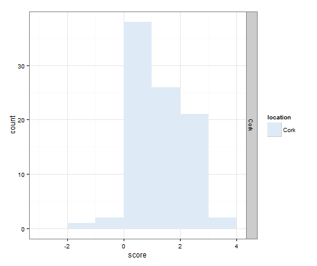

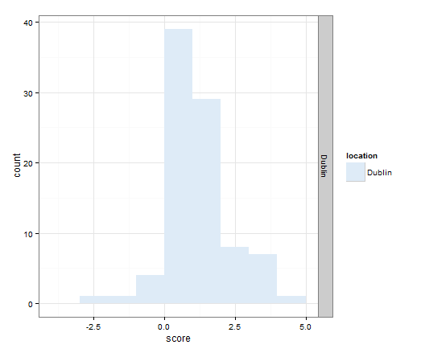

Galway

Limerick

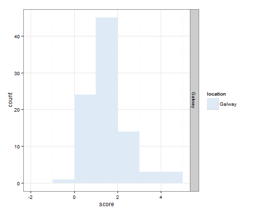

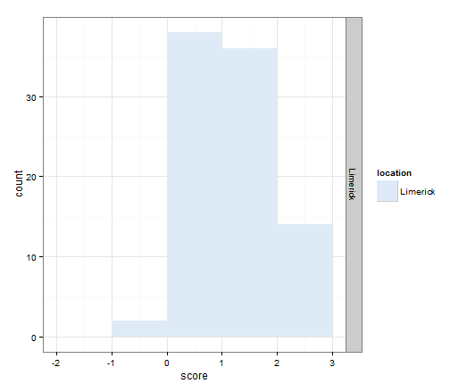

Waterford

All five cities

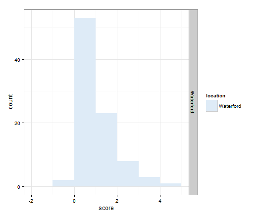

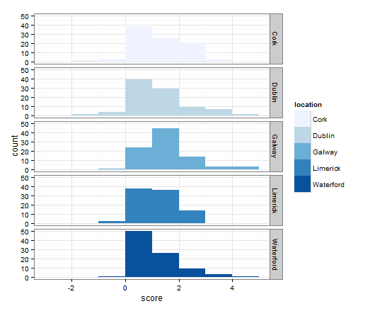

The algorithm that gives us the charts above matches positive and negative words with the Minqing Hu and Bing Liu dictionaries of positive and negative words. It then scores a tweet by the overall number of postive and negative words. Each positive words gets a score of +1 and each negative word gets a score of -1. For example a tweet could have three positive words and then scores 3, however it may also have 2 negative words and thus scores -2. Overall the score is 1, i.e. 3 + (-2). We can see that these five cities that the sentiment of tweets that mention jobs tend to be mainly neutral or positive.

This approach is simple and doesn’t really handle sarcasm very well. For sarcasm a more complicated alogrithm would be needed that looks at words in the context of the sentence as well as exclamation points and emoticons. Perhaps a dictionary of emoticons would be a useful way of handling sarcasm, as a tweeter might post something like “It’s raining today, awesome, cool :(” While in the first alogrithm this tweet would score 2 for awesome and cool and -1 for raining thus giving a positive score of 1, however the emoticon would effectively overrule that score and classify the sentiment as negative. This would be a start. For sarcasm without emoticons we are stepping a little deeper into the area of artificial intelligence and to start with non-naieve bayes algorithm could be used. In this case words would be considered to be dependent/in context rather than independent. However this would be complex and be greedy (use up alot of memory). For now of course this is distasteful to data analysts doing this as hobby, but as computers become powerful this approach may not be so bad.

# Sentiment cloud for tweets from Cork, Dublin, Galway, Limerick, Waterford:

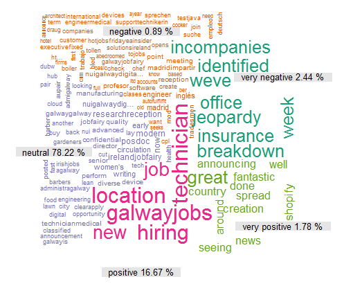

In the word cloud each word is graded for sentiment according to the datumbox sentiment analysis api. Accordingly the scores are going to be different to those above. The cloud works well for very positive and very neutral, but scores alot of words under positive and negative that look a little out of place. This cloud could be done again using the scoring algorithm outlined above.